| Babcock Lake | Babcock Lake Estates | Town(s) of Grafton | Rensselaer County |
| --- | --- | --- | --- |

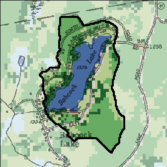

## Babcock Lake – 2018 Sampling Season Results

Open Water Indicators

2018 Sampling Results

Seasonal Change

Season Avg

Decadal Average

Decadal Trend?

Longterm Avg

Longterm Trend?

05-27

06-11

06-27

07-09

07-23

08-05

08-20

09-03

Clarity (m)

3.6

3.5

4.5

5

5.2

4.2

4

3.8

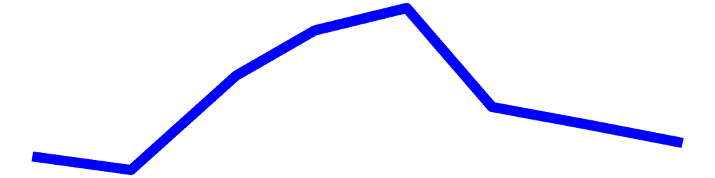

4.3

4.2

4.1

Surface TP (mg/L)

0.009

0.009

0.006

0.008

0.008

0.006

0.006

0.006

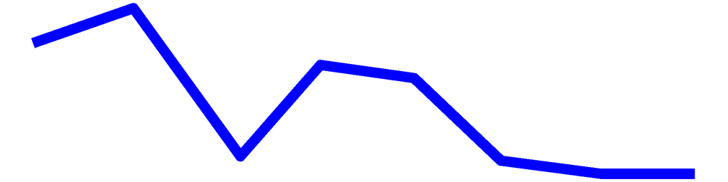

0.007

0.01

0.01

Surface TDP (mg/L)

0.006

0.003

0.004

0.005

0.009

0.004

0.002

0

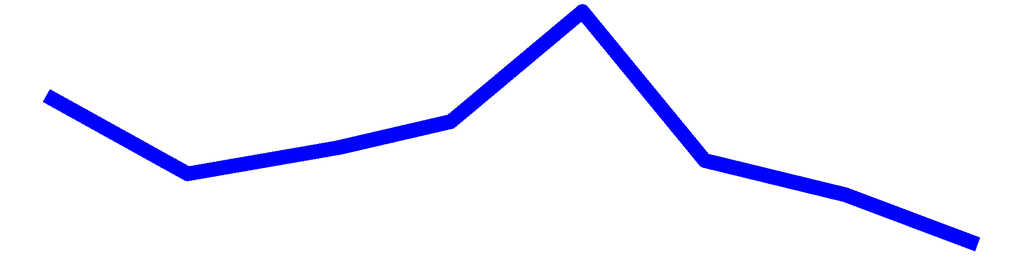

0.004

Deep TP (mg/L)

0.015

0.051

0.715

0.04

0.033

0.12

0.015

0.024

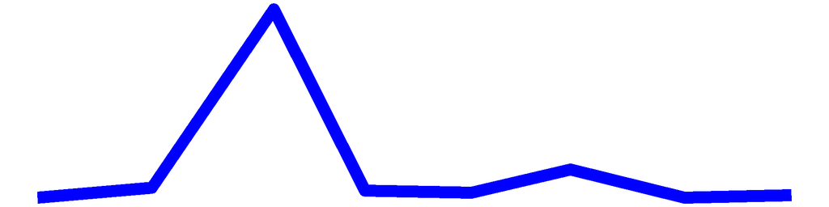

0.127

0.041

0.037

Deep TDP (mg/L)

0.005

0.002

0.024

0.011

0.01

0.018

0.005

0.005

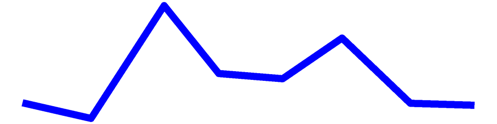

0.01

TN (mg/L)

0.568

0.425

0.416

0.339

0.446

0.399

0.309

0.312

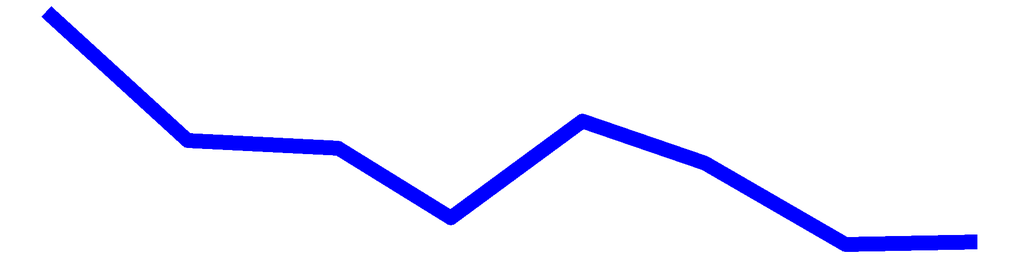

0.402

0.355

0.352

TDN (mg/L)

0.489

0.422

0.448

0.355

0.458

0.398

0.328

0.282

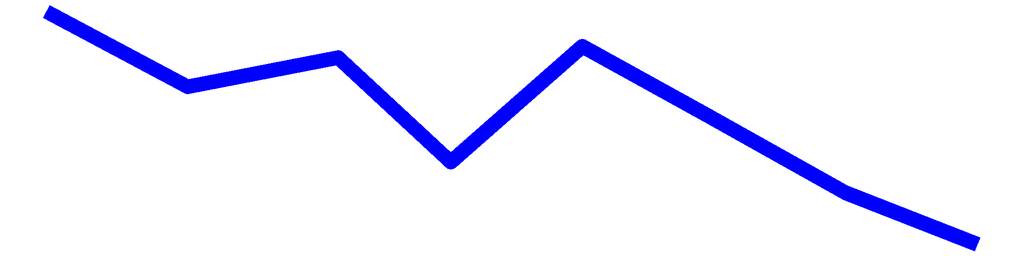

0.398

0.2

0.2

TN:TP

66

45

69

42

57

68

55

56

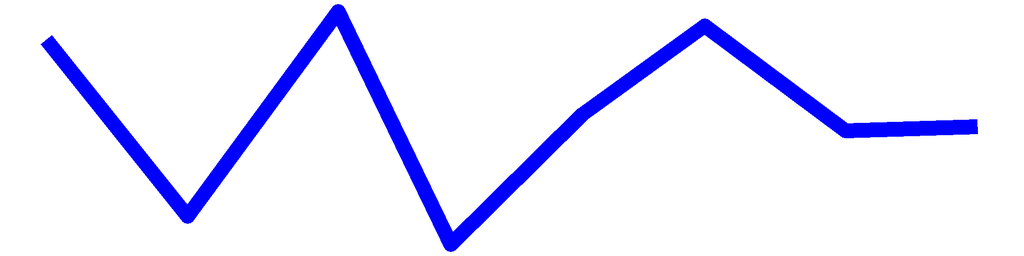

57

42

47

Surface NH3 (mg/L)

0.024

0.058

0.014

0.017

0.034

0.025

0.01

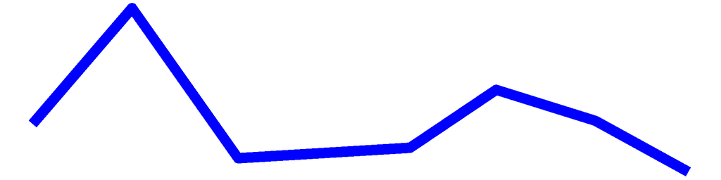

0.026

0.025

0.023

Deep NH3 (mg/L)

0.059

0.174

0.695

0.257

0.111

0.93

0.044

0.28

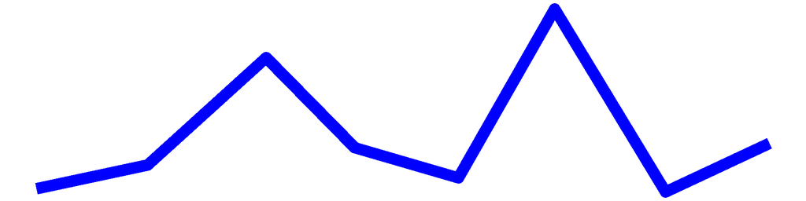

0.319

0.233

0.256

Chl.a (ug/L)

2.5

3.8

1.1

1.5

1.7

2

2.3

2.4

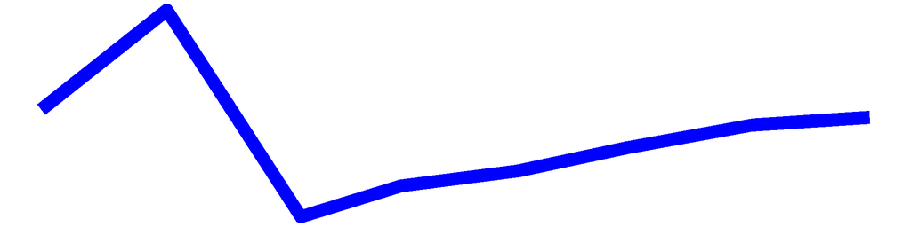

2.1

2.2

4.3

pH

7.8

7.5

7.8

7.7

7.5

7.4

7.4

7

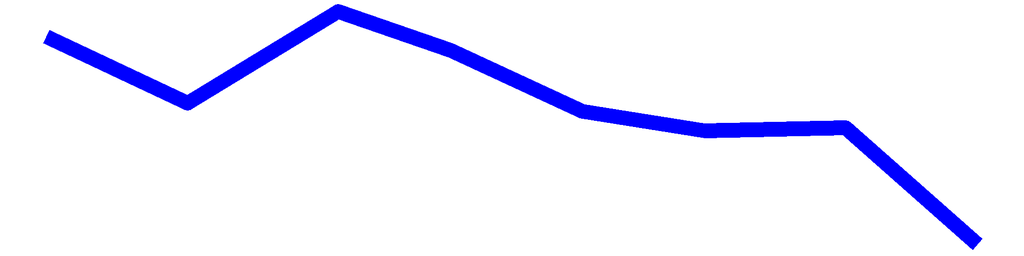

7.5

7.5

7.5

Cond (umho/cm)

97

93

90

81

86

85

86

86

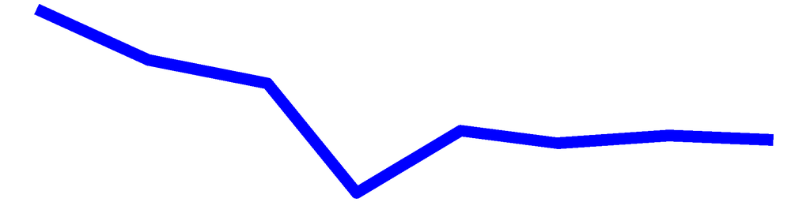

88

88

86

Surface Chloride (mg/L)

15

13

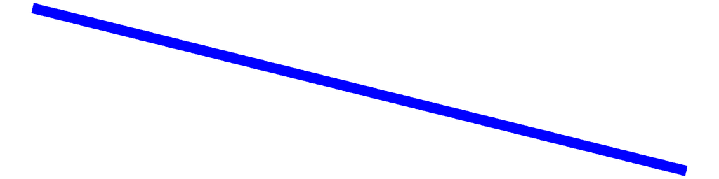

14

10

10

Upper Temp (degC)

23

24

25

29

29

28

27

28

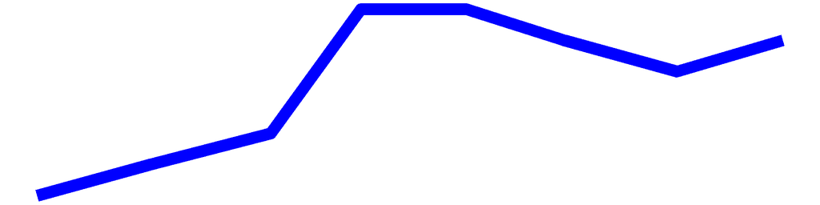

27

25

23

Deep Temp (degC)

13

11

13

12

14

12

18

13

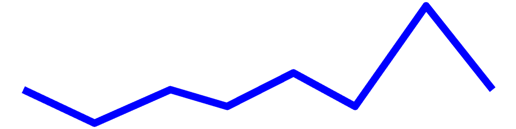

13

13

12

FP BG Chl.a (ug/L)

0

0.4

0.1

0.4

0.4

1

1.2

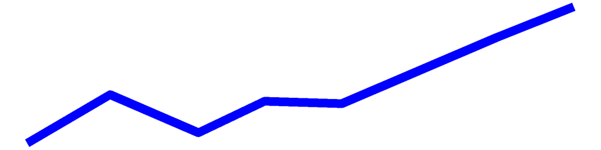

0.5

0.1

0.1

### NYHABs notifications

#### Were there any reported HABs this season? **No.**

### Shoreline HAB Sample Dates 2018

There were no shoreline HAB samples taken this season.

### HABs Status

#### Open Water Algae

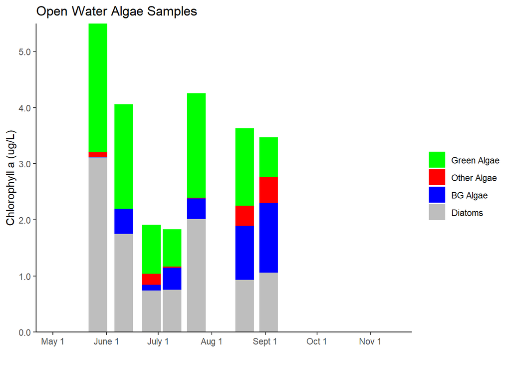

## Babcock Lake Long-Term Trend Analysis

#### Clarity

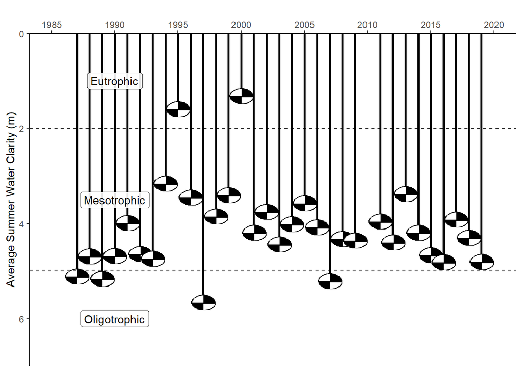

#### Chlorophyll *a*

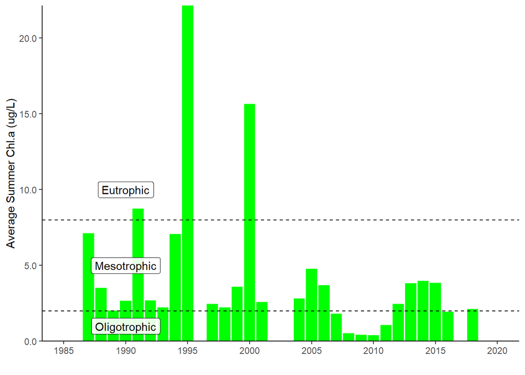

#### Surface and Deep Phosphorus

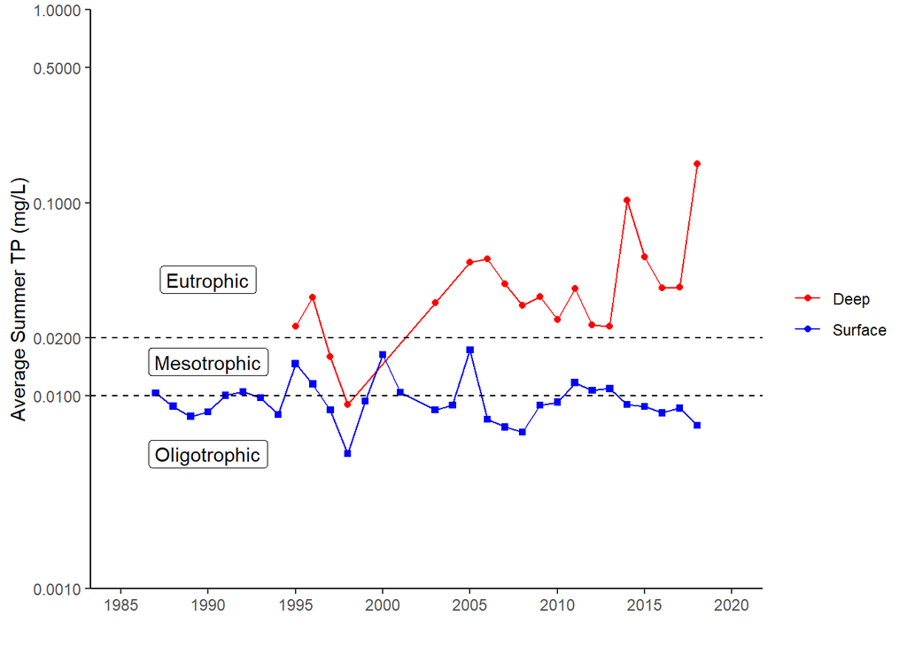

#### Nitrogen

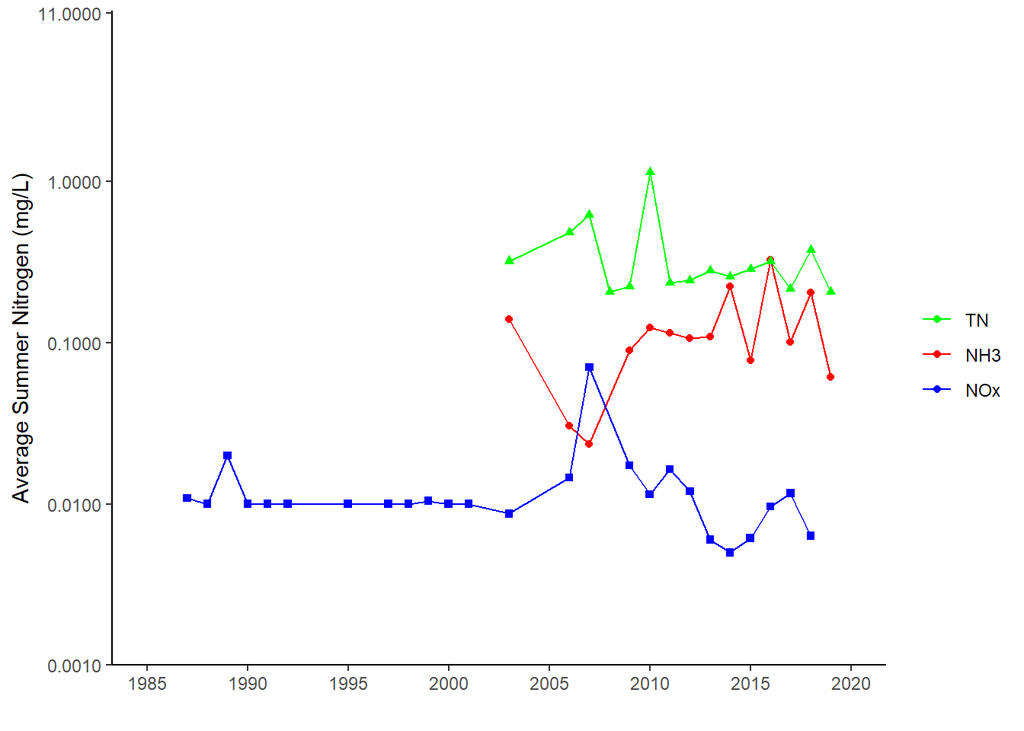

#### TN : TP

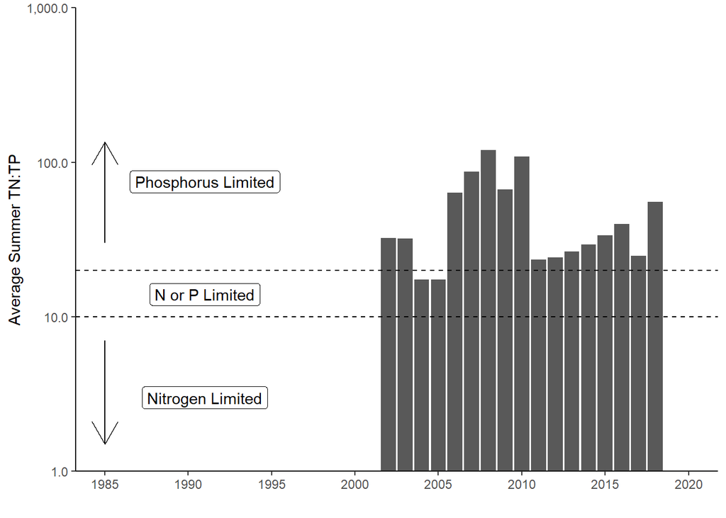

#### pH

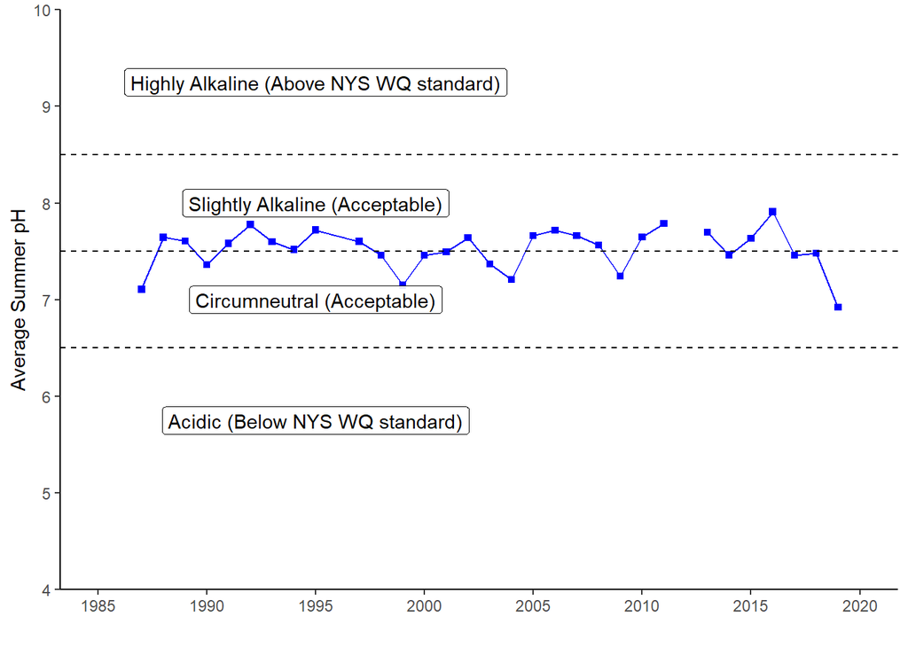

#### Specific Conductance

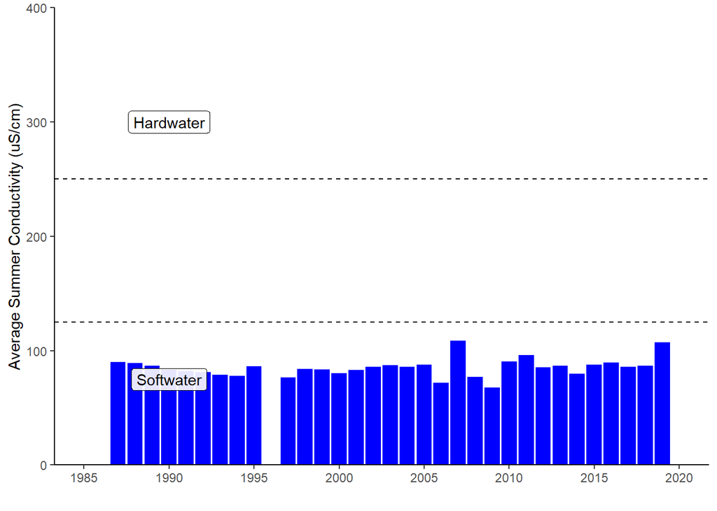

#### Calcium

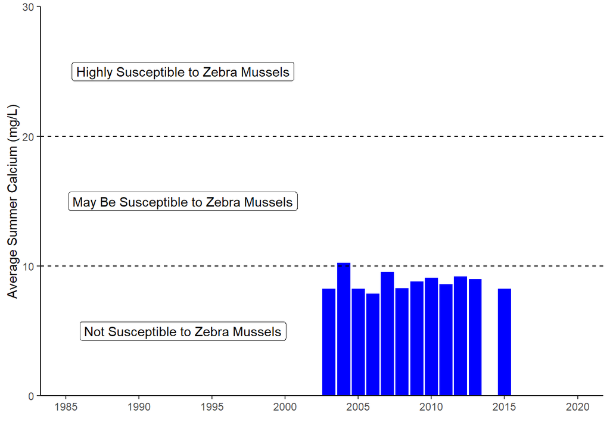

#### Chloride

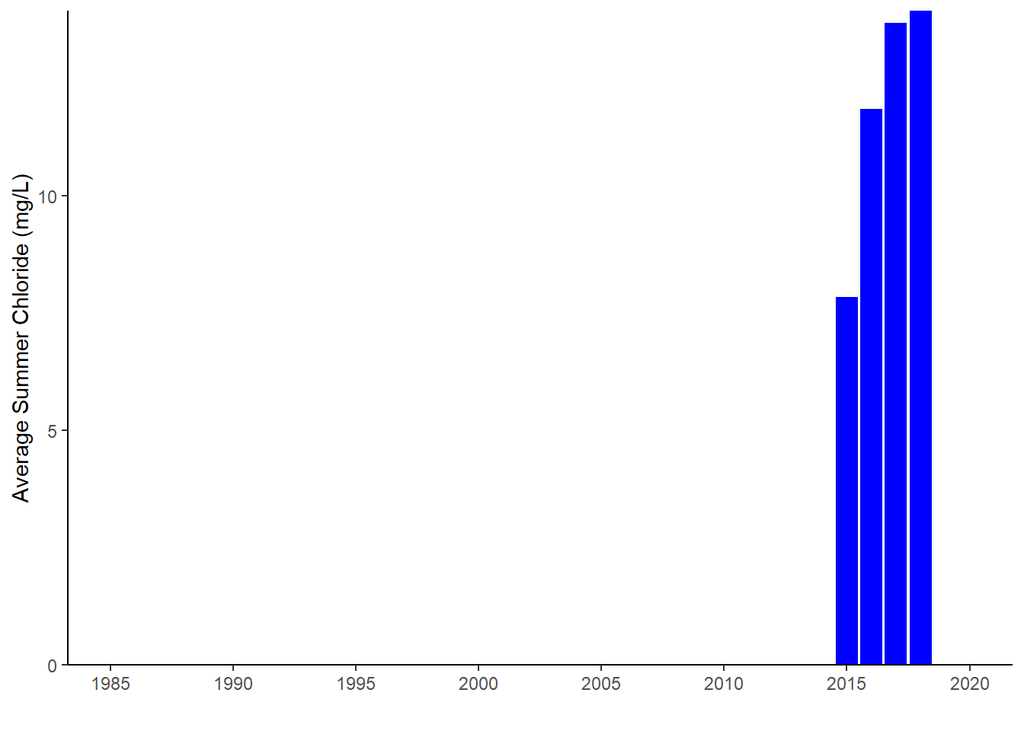

#### Color

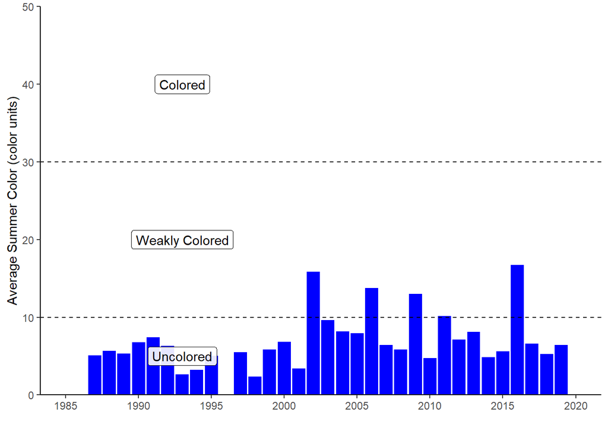

#### Surface and Deep Temperature

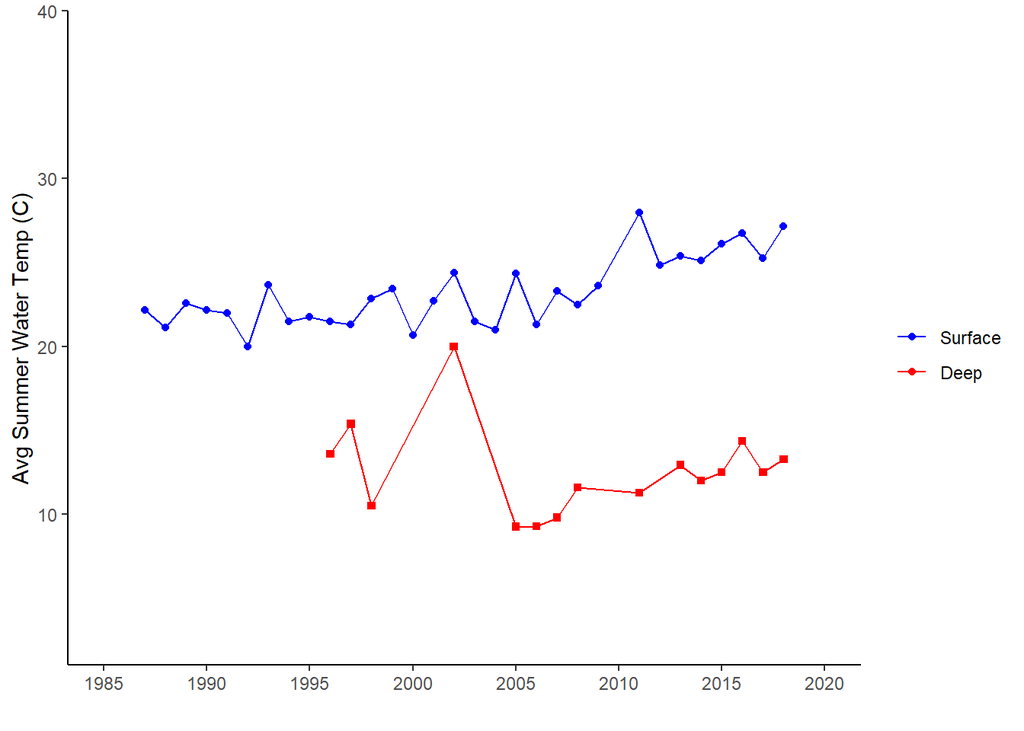

#### Lake Perception

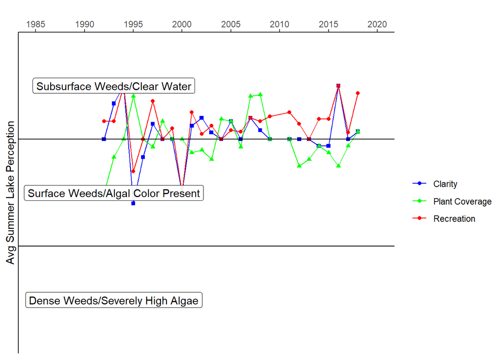